# Model Selection, Cross-Validation, and Regularization

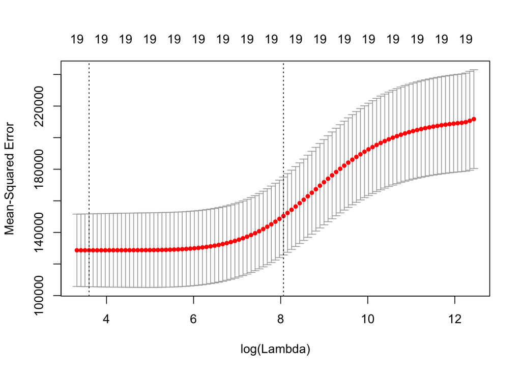

```r
set.seed(1)
train <- sample(1:nrow(X), 210)
test <- (-train)
y.test <- y[test]

# RIDGE
cv.out <- cv.glmnet(X[train,], y[train], alpha=0)  # Find best lambda
plot(cv.out)
```

```r
bestlam.r <- cv.out$lambda.min
print(paste("Optimal lambda:", round(bestlam.r,3)))
```

```
## [1] "Optimal lambda: 36.576"
```

```r
predict(ridge.mod, s=bestlam.r, type = "coefficients")[1:20,]  # Best ridge regression model
```

```
##   (Intercept)         AtBat          Hits         HmRun          Runs
##  6.241428e+01 -4.930832e-01  2.296882e+00 -1.385474e+00  1.110477e+00
##           RBI         Walks         Years        CAtBat         CHits
##  7.755174e-01  2.999884e+00 -7.563493e+00  3.691778e-03  1.198356e-01
##        CHmRun         CRuns          CRBI        CWalks       LeagueN
##  6.621278e-01  2.470793e-01  2.338690e-01 -2.058511e-01  4.961218e+01
##     DivisionW       PutOuts       Assists        Errors    NewLeagueN
## -1.208793e+02  2.572746e-01  1.425053e-01 -3.501714e+00 -1.372009e+01
```

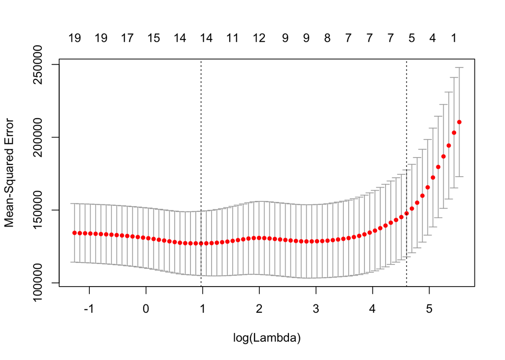

```r
# LASSO
cv.out <- cv.glmnet(X[train,], y[train], alpha=1)  # Find best lambda
plot(cv.out)
```

```r
bestlam.l <- cv.out$lambda.min
print(paste("Optimal lambda:", round(bestlam.l,3)))
```

```
## [1] "Optimal lambda: 2.641"
```

```r
predict(lasso.mod, s=bestlam.l, type = "coefficients")[1:20,]  # Best LASSO regression model
```

```
##  (Intercept)        AtBat         Hits        HmRun         Runs
##  124.1430078   -1.5557245    5.6830743    0.0000000    0.0000000
##          RBI        Walks        Years       CAtBat        CHits
##    0.0000000    4.7375354   -9.5924702    0.0000000    0.0000000
##       CHmRun        CRuns         CRBI       CWalks      LeagueN
##    0.5229904    0.6637874    0.3875519   -0.5318693   32.2219192
##    DivisionW      PutOuts      Assists       Errors   NewLeagueN
## -119.2561455    0.2727829    0.1747881   -2.0717182    0.0000000
```

In the ridge model, the explanatory variables have been minimised where insignificant variables are close to 0, but are not zero, and the significant variables are small. This is contrasted with the LASSO model where insignificant variables are zero, and the significant variables are large, relative to the significant values of the ridge model. Both models are similar in identifying which variables are significant and which are not.

```r
trn <- hitters[train,]
tst <- hitters[-train,] # Held-out test set

stepwise <- lm(Salary ~ AtBat + Hits + Walks + CAtBat + CRuns +
                 CRBI + CWalks + Division + PutOuts + Assists, data = trn)
step.pred <- predict(stepwise, tst)
RMSEs <- sqrt(mean((step.pred - y.test)^2))  # Predictive RMSE of best stepwise model

ridge.pred <- predict(ridge.mod, s=bestlam.r, newx=X[test,])
RMSEr <- sqrt(mean((ridge.pred - y.test)^2))  # Predictive RMSE of best ridge model

lasso.pred <- predict(lasso.mod, s=bestlam.l, newx=X[test,])
RMSEl <- sqrt(mean((lasso.pred - y.test)^2))  # Predictive RMSE of best LASSO model

print(paste("RMSE (Stepwise):", round(RMSEs,3)))
```

```
## [1] "RMSE (Stepwise): 245.978"
```

```r
print(paste("RMSE (LASSO):", round(RMSEl,3)))
```

```
## [1] "RMSE (LASSO): 232.878"
```

```r
print(paste("RMSE (Ridge):", round(RMSEr,3)))
```

```
## [1] "RMSE (Ridge): 245.276"
```

The RMSE of the best LASSO regression is lowest, followed by the best ridge regression, and then Best-Stepwise selection model. Based on this criterion, the LASSO model is the best.